# R Notebook

```r
library(tm)
library(tidytext)
```

```r
getwd()
```

```
[1] "C:/Users/Saturn/Desktop/DATA_SCIENCE_UNI"
```

```r
setwd("C:/Users/Saturn/Desktop/DATA_SCIENCE_UNI")
```

```r
docs <- Corpus(DirSource("./texts",encoding = "UTF-8"))
```

```r
str(docs)
```

```
List of 11
 $ Trump Black History Month Speech.txt         :List of 2
  ..$ content: chr "Well, the election, it came out really well. Next time we’ll triple the number or quadruple it. We want to get "| __truncated__
  ..$ meta   :List of 7
  .. ..$ author       : chr(0)
  .. ..$ datetimestamp: POSIXlt[1:1], format: "2023-03-19 15:07:04"
  .. ..$ description  : chr(0)
  .. ..$ heading      : chr(0)
  .. ..$ id           : chr "Trump Black History Month Speech.txt"
  .. ..$ language     : chr "en"
  .. ..$ origin       : chr(0)
  .. ..- attr(*, "class")= chr "TextDocumentMeta"
  ..- attr(*, "class")= chr [1:2] "PlainTextDocument" "TextDocument"
 $ Trump CIA Speech.txt                         :List of 2
  ..$ content: chr "Well, I want to thank everybody.  Very, very special people.  And it is true, this is my first stop, officially"| __truncated__
  ..$ meta   :List of 7
  .. ..$ author       : chr(0)
  .. ..$ datetimestamp: POSIXlt[1:1], format: "2023-03-19 15:07:04"
  .. ..$ description  : chr(0)
  .. ..$ heading      : chr(0)
  .. ..$ id           : chr "Trump CIA Speech.txt"
  .. ..$ language     : chr "en"
  .. ..$ origin       : chr(0)
  .. ..- attr(*, "class")= chr "TextDocumentMeta"
  ..- attr(*, "class")= chr [1:2] "PlainTextDocument" "TextDocument"
 $ Trump Congressional Address.txt              :List of 2
  ..$ content: chr "Mr. Speaker, Mr. Vice President, Members of Congress, the First Lady of the United States, and Citizens of Amer"| __truncated__
  ..$ meta   :List of 7
  .. ..$ author       : chr(0)
  .. ..$ datetimestamp: POSIXlt[1:1], format: "2023-03-19 15:07:04"
  .. ..$ description  : chr(0)
  .. ..$ heading      : chr(0)
  .. ..$ id           : chr "Trump Congressional Address.txt"
  .. ..$ language     : chr "en"
  .. ..$ origin       : chr(0)
  .. ..- attr(*, "class")= chr "TextDocumentMeta"
  ..- attr(*, "class")= chr [1:2] "PlainTextDocument" "TextDocument"
 $ Trump CPAC Speech.txt                        :List of 2
  ..$ content: chr " Thank you, everybody. So great to be with you. Thank you. \nGreat to be back at CPAC. It's a place I have real"| __truncated__
  ..$ meta   :List of 7
```

[output cut: 79 more lines]

```
  .. ..- attr(*, "class")= chr "TextDocumentMeta"
  ..- attr(*, "class")= chr [1:2] "PlainTextDocument" "TextDocument"
 $ Trump Response to Healthcare Bill Failure.txt:List of 2
  ..$ content: chr " Thank you very much. We were very close, and it was a very, very tight margin. We had no Democrat support. We "| __truncated__
  ..$ meta   :List of 7
  .. ..$ author       : chr(0)
  .. ..$ datetimestamp: POSIXlt[1:1], format: "2023-03-19 15:07:04"
  .. ..$ description  : chr(0)
  .. ..$ heading      : chr(0)
  .. ..$ id           : chr "Trump Response to Healthcare Bill Failure.txt"
  .. ..$ language     : chr "en"
  .. ..$ origin       : chr(0)
  .. ..- attr(*, "class")= chr "TextDocumentMeta"
  ..- attr(*, "class")= chr [1:2] "PlainTextDocument" "TextDocument"
 - attr(*, "class")= chr [1:2] "SimpleCorpus" "Corpus"
```

```r
summary(docs)
```

```
                                              Length Class             Mode
Trump Black History Month Speech.txt          2      PlainTextDocument list
Trump CIA Speech.txt                          2      PlainTextDocument list
Trump Congressional Address.txt               2      PlainTextDocument list
Trump CPAC Speech.txt                         2      PlainTextDocument list
Trump Florida Rally 2-18-17.txt               2      PlainTextDocument list
Trump Immigration Speech 8-31-16.txt          2      PlainTextDocument list
Trump Inauguration Speech.txt                 2      PlainTextDocument list
Trump National Prayer Breakfast.txt           2      PlainTextDocument list
Trump Nomination Speech.txt                   2      PlainTextDocument list
Trump Police Chiefs Speech.txt                2      PlainTextDocument list
Trump Response to Healthcare Bill Failure.txt 2      PlainTextDocument list
```

access a specific doc:

```r
inspect(docs[1])
```

```
<<SimpleCorpus>>
Metadata:  corpus specific: 1, document level (indexed): 0
Content:  documents: 1

                                                                                                                                                                                                                                                                                                            …
Well, the election, it came out really well. Next time we’ll triple the number or quadruple it. We want to get it over 51, right? At least 51.\n\nWell this is Black History Month, so this is our little breakfast, our little get-together. Hi Lynn, how are you? Just a few notes. During this month, we …
```

bc the data structure is a list so we can also access the doc by the following syntax

```r
docs[[1]]
```

```
<<PlainTextDocument>>
Metadata:  7
Content:  chars: 3988
```

```r
docs[[1]]$content
```

```
[1] "Well, the election, it came out really well. Next time we’ll triple the number or quadruple it. We want to get it over 51, right? At least 51.\n\nWell this is Black History Month, so this is our little breakfast, our little get-together. Hi Lynn, how are you? Just a few notes. During this month…
```

```r
docs[[1]]$meta
```

```
  author       : character(0)
  datetimestamp: 2023-03-19 15:07:04
  description  : character(0)
  heading      : character(0)
  id           : Trump Black History Month Speech.txt
  language     : en
  origin       : character(0)
```

#1. convert words into lowercase with tm package using : tm_map()

```r
docs<-tm_map(docs,content_transformer(tolower))
docs[[1]]$content
```

```
[1] "well, the election, it came out really well. next time we’ll triple the number or quadruple it. we want to get it over 51, right? at least 51.\n\nwell this is black history month, so this is our little breakfast, our little get-together. hi lynn, how are you? just a few notes. during this month…
```

#2.Remove very common words of English (called : stopwords) like this:

```r
docs<-tm_map(docs,removeWords,stopwords("English"))
docs[[1]]$content
```

```
[1] "well,  election,  came  really well. next time ’ll triple  number  quadruple .  want  get   51, right?  least 51.\n\nwell   black history month,     little breakfast,  little get-together. hi lynn,   ? just   notes.   month,  honor  tremendous history  african-americans throughout  country. thr…
```

#3.remove punctuation marks:

```r
docs<- tm_map(docs,removePunctuation)
docs[[1]]$content
```

```
[1] "well  election  came  really well next time ’ll triple  number  quadruple   want  get   51 right  least 51\n\nwell   black history month     little breakfast  little gettogether hi lynn    just   notes   month  honor  tremendous history  africanamericans throughout  country throughout  world   …
```

```r
trumpDTM <- DocumentTermMatrix(docs)
trumpDTM
```

```
<<DocumentTermMatrix (documents: 11, terms: 3677)>>
Non-/sparse entries: 8355/32092
Sparsity           : 79%
Maximal term length: 18
Weighting          : term frequency (tf)
```

#view the contents of documentterm maxtrix with inspect()

```r
inspect(trumpDTM)
```

```
<<DocumentTermMatrix (documents: 11, terms: 3677)>>
Non-/sparse entries: 8355/32092
Sparsity           : 79%
Maximal term length: 18
Weighting          : term frequency (tf)
Sample             :
                                               Terms
Docs                                            america country going great know now one
  Trump CIA Speech.txt                                0       4    21     7   20   8  12
  Trump Congressional Address.txt                    28      17     3    13    5  10  13
  Trump CPAC Speech.txt                              16      22    47    35   27  17  24
  Trump Florida Rally 2-18-17.txt                    12      30    61    33   14  19  17
  Trump Immigration Speech 8-31-16.txt                8      43    64    19   20  16  22
  Trump Inauguration Speech.txt                      18       9     1     6    0   6   8
  Trump National Prayer Breakfast.txt                 8       7    11    13    8   3   7
  Trump Nomination Speech.txt                        25      25    17     8    4   9  15
  Trump Police Chiefs Speech.txt                      5      14    17    18   19  13  14
  Trump Response to Healthcare Bill Failure.txt       0       2    21     9   10   6   4
                                               Terms
Docs                                            people want will
  Trump CIA Speech.txt                              21    7    8
  Trump Congressional Address.txt                   15    9   56
  Trump CPAC Speech.txt                             69   22   40
  Trump Florida Rally 2-18-17.txt                   35   37   33
  Trump Immigration Speech 8-31-16.txt              51   18   97
  Trump Inauguration Speech.txt                     10    1   42
  Trump National Prayer Breakfast.txt               19   13   21
  Trump Nomination Speech.txt                       14    7   86
  Trump Police Chiefs Speech.txt                    32   14   23
  Trump Response to Healthcare Bill Failure.txt      8    7   20
```

```r
inspect(trumpDTM[1:2,1:2])
```

```
<<DocumentTermMatrix (documents: 2, terms: 2)>>
Non-/sparse entries: 2/2
Sparsity           : 50%
Maximal term length: 15
Weighting          : term frequency (tf)
Sample             :
                                      Terms
Docs                                   actually africanamerican
  Trump Black History Month Speech.txt        1               1
  Trump CIA Speech.txt                        0               0
```

there are many 0s -> wastes memory (sparse )of the matrix -> remove 0(low freq terms)

```r
trumpDTMS<- removeSparseTerms(trumpDTM,0.05)
trumpDTMS
```

```
<<DocumentTermMatrix (documents: 11, terms: 22)>>
Non-/sparse entries: 242/0
Sparsity           : 0%
Maximal term length: 7
Weighting          : term frequency (tf)
```

```r
inspect(trumpDTM[,c("news","fake","america","great")])
```

```
<<DocumentTermMatrix (documents: 11, terms: 4)>>
Non-/sparse entries: 29/15
Sparsity           : 34%
Maximal term length: 7
Weighting          : term frequency (tf)
Sample             :
                                               Terms
Docs                                            america fake great news
  Trump Black History Month Speech.txt                2    3     2    3
  Trump Congressional Address.txt                    28    0    13    1
  Trump CPAC Speech.txt                              16   13    35    8
  Trump Florida Rally 2-18-17.txt                    12    3    33    3
  Trump Immigration Speech 8-31-16.txt                8    0    19    1
  Trump Inauguration Speech.txt                      18    0     6    0
  Trump National Prayer Breakfast.txt                 8    0    13    0
  Trump Nomination Speech.txt                        25    0     8    1
  Trump Police Chiefs Speech.txt                      5    0    18    0
  Trump Response to Healthcare Bill Failure.txt       0    0     9    0
```

#Exercise: explore in which documents and with what occurence the term free ,russia, and news occur

```r
inspect(trumpDTM[,c("free","russia","news")])
```

```
<<DocumentTermMatrix (documents: 11, terms: 3)>>
Non-/sparse entries: 12/21
Sparsity           : 64%
Maximal term length: 6
Weighting          : term frequency (tf)
Sample             :
                                      Terms
Docs                                   free news russia
  Trump Black History Month Speech.txt    0    3      0
  Trump CIA Speech.txt                    0    0      0
  Trump Congressional Address.txt         6    1      0
  Trump CPAC Speech.txt                   0    8      0
  Trump Florida Rally 2-18-17.txt         1    3      0
  Trump Immigration Speech 8-31-16.txt    0    1      1
  Trump Inauguration Speech.txt           1    0      0
  Trump National Prayer Breakfast.txt     1    0      0
  Trump Nomination Speech.txt             4    1      0
  Trump Police Chiefs Speech.txt          0    0      0
```

##analyse the occurrence and co-occurence pf words.Find the most frequent words in the corpus

```r
trumpFreqTerms <- findFreqTerms(trumpDTM, lowfreq = 50)
trumpFreqTerms
```

```
 [1] "america"     "american"    "can"         "country"     "even"        "get"
 [7] "going"       "good"        "great"       "jobs"        "just"        "law"
[13] "like"        "make"        "many"        "much"        "never"       "new"
[19] "now"         "one"         "people"      "really"      "right"       "said"
[25] "say"         "take"        "thank"       "think"       "time"        "want"
[31] "way"         "will"        "work"        "world"       "years"       "—"
[37] "’re"         "’s"          "also"        "back"        "believe"     "come"
[43] "know"        "must"        "states"      "tell"        "united"      "immigration"
[49] "look"
```

###sum the frequency values for each term in the DTM using colSums() . Convert DTM to normal Matrix first using as.matrix() colSums() return a name vector where the elements are named by the terms and the values of the vector elements is the term frequency

```r
trumpFreqTerms <- colSums(as.matrix(trumpDTM))
head(trumpFreqTerms)
```

```
        actually  africanamerican africanamericans              ago           almost
              15                5                1               18               12
         amazing
              23
```

### use the sort() to order the terms by freq

```r
sort(trumpFreqTerms, decreasing = TRUE)
```

```
           will          people           going         country           great
            428             278             265             174             163
           want             one            know         america             now
            140             139             127             122             111
             ’s        american           thank           right            many
            109             107             105             102             101
            can               —            just           never            said
            100              99              88              83              83
            get            like            time           think            back
             79              79              78              77              75
            way             new            much     immigration             say
             71              69              68              67              66
         states            make            take            work          united
             65              64              64              64              64
            ’re         believe             law            good          really
             61              60              59              58              57
          world            even            come            jobs           years
             56              55              55              54              54
           also            must            look            tell       americans
             54              53              52              50              49
          every             see          nation            year             big
             49              48              48              47              45
           love          better            last             lot           first
             45              44              44              44              44
      president          system     enforcement            ever        citizens
             44              44              43              42              42
        illegal          across          things             let             job
             42              41              40              40              38
           care          border        security               –             day
             37              37              37              37              36
            got          happen             win            long            safe
             36              36              36              36              35
            bad       countries             put           folks        together
             35              35              35              34              34
           seen         protect          number           today            well
             34              34              33              33              33
      everybody            made            need           trade         workers
             32              32              32              32              32
           plan         support             god        military  administration
             31              31              30              30              30
```

[output cut: 346 more lines]

```
        society           steel      struggling           susan          thomas
              4               4               4               4               4
         thrive    transpacific         uniform            upon       viciously
              4               4               4               4               4
          wants             yes            beat          beyond         cabinet
              4               4               4               4               4
         closed      completely        consider     consultants           delay
              4               4               4               4               4
        doubled        endorsed          energy            firm           happy
              4               4               4               4               4
       industry            lock           makes           minds           reads
              4               4               4               4               4
            sat         setting             sit       situation      terrorists
              4               4               4               4               4
 [ reached getOption("max.print") -- omitted 2677 entries ]
```

### another way to do this is to convert the vector into dataframe , and then order this by frequency to see the most popular words that trump uses with the arrange()

```r
trumpFreqTermsDF <- data.frame(word = names(trumpFreqTerms), freq= trumpFreqTerms)
```

```r
library(dplyr)
```

```r
arrange(trumpFreqTermsDF,desc(freq))
```

| word | freq |
| --- | --- |
| will | 428 |
| people | 278 |
| going | 265 |
| country | 174 |
| great | 163 |
| want | 140 |
| one | 139 |
| know | 127 |
| america | 122 |
| now | 111 |

[output cut: 990 more lines]

### draw a barchart using barplot to show the most frequent words like this :

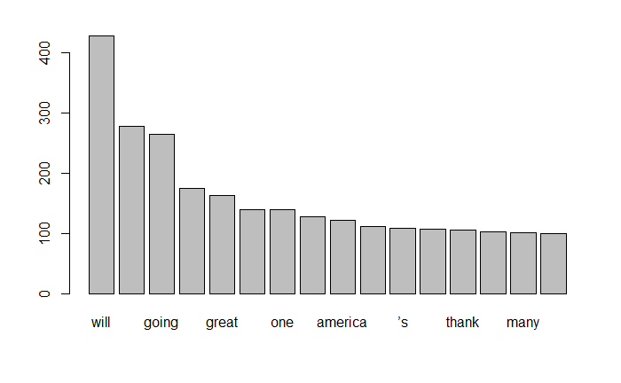

```r
trumpFreqTermsDF100 <- subset(trumpFreqTermsDF,freq >=100) %>% arrange(desc(freq))
barplot(trumpFreqTermsDF100$freq,names.arg = trumpFreqTermsDF100$word)
```

# wordcloud

```r
install.packages("wordcloud")
```

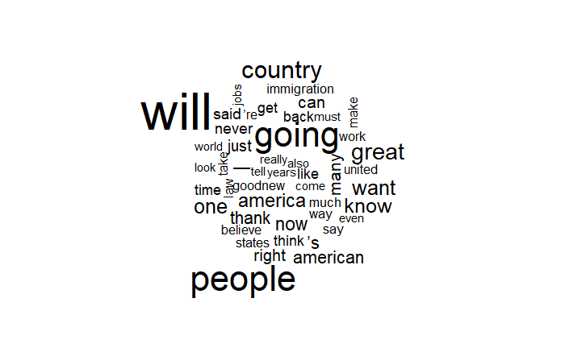

```r
library(wordcloud)
set.seed(142)
wordcloud(trumpFreqTermsDF$word,trumpFreqTermsDF$freq, min.freq = 50)
```

### identifying words that occur together

if 2 words appear together then the corr is 1. if never then corr is 0

```r
findAssocs(trumpDTM,"fake", corlimit = 0.6)
```

```
$fake
          news            saw          delay        setting        sources        stories
          0.97           0.97           0.97           0.97           0.97           0.97
         42000            abc        angeles         anthem   anticipation      apologize
          0.95           0.95           0.95           0.95           0.95           0.95
     approvals         assume     authorized     background       battered          beach
          0.95           0.95           0.95           0.95           0.95           0.95
       beloved         blocks    bloodsucker        boasted          bored           boss
          0.95           0.95           0.95           0.95           0.95           0.95
      brandnew       buildups        cabinet    campaigning      campbells       carolina
          0.95           0.95           0.95           0.95           0.95           0.95
      carriers    catastrophe    caterpillar            cbs       changing       checking
          0.95           0.95           0.95           0.95           0.95           0.95
         chris      christian           cmon       comments      commotion      concerned
          0.95           0.95           0.95           0.95           0.95           0.95
      conclude    conclusions        connect      connected    consultants  controversial
          0.95           0.95           0.95           0.95           0.95           0.95
      covering         covers           cpac        creates      criticize       crushing
          0.95           0.95           0.95           0.95           0.95           0.95
       cunning           dare        darling           dead        dealing      dedicated
          0.95           0.95           0.95           0.95           0.95           0.95
        deduct      defensive       delegate     deplorable       deterred    development
          0.95           0.95           0.95           0.95           0.95           0.95
    disappoint      disgusted     disservice          doors         dreamt        dropped
          0.95           0.95           0.95           0.95           0.95           0.95
           dry          dudes     efficiency          elect      elections   embarrassing
          0.95           0.95           0.95           0.95           0.95           0.95
        europe       everyday       exciting      expanding      expensive        explain
          0.95           0.95           0.95           0.95           0.95           0.95
          fall        feeling        finding      finishing           fire      gentleman
          0.95           0.95           0.95           0.95           0.95           0.95
     geography          gives            gop    hardworking           heat      honorable
          0.95           0.95           0.95           0.95           0.95           0.95
          hurt        implode     inaccurate         indeed    investments   irredeemable
          0.95           0.95           0.95           0.95           0.95           0.95
           jim          knock        largely          legit         lights            los
          0.95           0.95           0.95           0.95           0.95           0.95
         major         marked        measure        medical       meetings       mentions
          0.95           0.95           0.95           0.95           0.95           0.95
      mercedes      ministers      misbehave           miss      movements      narrative
```

[output cut: 80 more lines]

```
          0.60           0.60           0.60           0.60           0.60           0.60
 contributions   corporations          decay      delegates      disrepair            era
          0.60           0.60           0.60           0.60           0.60           0.60
     eradicate    evangelical           eyes           flow          fully          hello
          0.60           0.60           0.60           0.60           0.60           0.60
      industry          likes       lobbyist         losing          lucky       michigan
          0.60           0.60           0.60           0.60           0.60           0.60
       minimum        nobodys           ohio      opponents     percentage           play
          0.60           0.60           0.60           0.60           0.60           0.60
    production       quagmire       recently       reported            sat      sensitive
          0.60           0.60           0.60           0.60           0.60           0.60
         sorry     standpoint    substantial         summer      surprised     terrorists
          0.60           0.60           0.60           0.60           0.60           0.60
      throwing           warm       wasteful         worker
          0.60           0.60           0.60           0.60
```

#4 text mining with tidytext data is in tidy format

```r
library(tidytext)
library(janeaustenr) > library(dplyr)
```

```
 [1] FALSE FALSE FALSE FALSE FALSE FALSE FALSE FALSE FALSE FALSE FALSE FALSE FALSE FALSE
```

```r
library(stringr)
```

```r
View(austen_books())
```

##use dplyr to provide summary of books

```r
austen_books()%>%group_by(book)%>%
summarise(total_lines= n())
```

| book | total_lines |
| --- | --- |
| Sense & Sensibility | 12624 |
| Pride & Prejudice | 13030 |
| Mansfield Park | 15349 |
| Emma | 16235 |
| Northanger Abbey | 7856 |
| Persuasion | 8328 |

### convert to tidy form which is a one token per row dataframe. word column contains in each row the word extracted in each line from text column

```r
austenTidyBooks <-austen_books()%>% unnest_tokens(word,text)
austenTidyBooks
```

| book | word |
| --- | --- |
| Sense & Sensibility | sense |
| Sense & Sensibility | and |
| Sense & Sensibility | sensibility |
| Sense & Sensibility | by |
| Sense & Sensibility | jane |
| Sense & Sensibility | austen |
| Sense & Sensibility | 1811 |
| Sense & Sensibility | chapter |
| Sense & Sensibility | 1 |
| Sense & Sensibility | the |

[output cut: 990 more lines]

#4.1 Computing word frequencies

```r
austenTidyBooks%>%count(word, sort = TRUE)
```

| word | n |
| --- | --- |
| the | 26351 |
| to | 24044 |
| and | 22515 |
| of | 21178 |
| a | 13408 |
| her | 13055 |
| i | 12006 |
| in | 11217 |
| was | 11204 |
| it | 10234 |

[output cut: 990 more lines]

##remove common words:

```r
data("stop_words")
austenTidyBooks<- austenTidyBooks%>%
anti_join(stop_words)
austenTidyBooks%>%
count(word,sort = TRUE)
```

| word | n |
| --- | --- |
| miss | 1855 |
| time | 1337 |
| fanny | 862 |
| dear | 822 |
| lady | 817 |
| sir | 806 |
| day | 797 |
| emma | 787 |
| sister | 727 |
| house | 699 |

[output cut: 990 more lines]

##filter out the book emma and the count words:

```r
austenTidyBooks%>%
filter(book=='Emma')%>%
count(word,sort = TRUE)
```

| word | n |
| --- | --- |
| emma | 786 |
| miss | 599 |
| harriet | 415 |
| weston | 389 |
| knightley | 356 |
| elton | 319 |
| jane | 282 |
| time | 279 |
| woodhouse | 277 |
| dear | 241 |

[output cut: 990 more lines]

#4.2 sentiment analysis to know if the text is positive or negative approach : look up words in sentiment dictionary(where words are labeled with sentiments), then count the number of words of different senitments to get overall score

```r
sentiments
```

| word | sentiment | lexicon | score |
| --- | --- | --- | --- |
| abacus | trust | nrc | NA |
| abandon | fear | nrc | NA |
| abandon | negative | nrc | NA |
| abandon | sadness | nrc | NA |
| abandoned | anger | nrc | NA |
| abandoned | fear | nrc | NA |
| abandoned | negative | nrc | NA |
| abandoned | sadness | nrc | NA |
| abandonment | anger | nrc | NA |
| abandonment | fear | nrc | NA |

[output cut: 990 more lines]

```r
get_sentiments("bing")
```

| word | sentiment |
| --- | --- |
| 2-faced | negative |
| 2-faces | negative |
| a+ | positive |
| abnormal | negative |
| abolish | negative |
| abominable | negative |
| abominably | negative |
| abominate | negative |
| abomination | negative |
| abort | negative |

[output cut: 990 more lines]

```r
install.packages('textdata')
```

[output not shown]

[output not shown]

[output not shown]

##count how many type of sentiments in nrc lexicon

```r
get_sentiments("nrc")%>%
group_by(sentiment)%>%
summarise(count=n())
```

| sentiment | count |
| --- | --- |
| anger | 1247 |
| anticipation | 839 |
| disgust | 1058 |
| fear | 1476 |
| joy | 689 |
| negative | 3324 |
| positive | 2312 |
| sadness | 1191 |
| surprise | 534 |
| trust | 1231 |

#let see which words in emma match those categorised as anger

###step1: filtering out words classified as anger from nrc sentiment lexicon

```r
nrcAnger <- get_sentiments("nrc")%>%
filter(sentiment == "anger")
nrcAnger
```

| word | sentiment |
| --- | --- |
| abandoned | anger |
| abandonment | anger |
| abhor | anger |
| abhorrent | anger |
| abolish | anger |
| abomination | anger |
| abuse | anger |
| accursed | anger |
| accusation | anger |
| accused | anger |

[output cut: 990 more lines]

### step 2: use inner_join() to join emma words and nrcAnger

```r
austenTidyBooks%>%
filter(book== "Emma")%>%
inner_join(nrcAnger)%>%
count(word,sort = TRUE)
```

| word | n |
| --- | --- |
| ill | 72 |
| bad | 60 |
| feeling | 56 |
| bear | 52 |
| words | 49 |
| obliging | 34 |
| evil | 33 |
| difficulty | 30 |
| spite | 24 |
| loss | 23 |

[output cut: 303 more lines]

###compare the books for proportion of words that match sentiment types. just using nrc lexicon and start with emma

```r
austenTidyBooks%>%
filter(book=="Emma")%>%
summarise(count=n())
```

| count |
| --- |
| 46775 |

### emma has 46775 words

### compare the words with the nrc lexicon using inner_join()

```r
austenTidyBooks%>%
filter(book=="Emma")%>%
inner_join(get_sentiments("nrc"))%>%
summarise(count=n())
```

| count |
| --- |
| 34141 |

```r
austenTidyBooks%>%
filter(book=="Emma")%>%
inner_join(get_sentiments("nrc"))%>%
group_by(sentiment)%>%
summarise(percent=(n()/34141)*100)
```

[output not shown]

###visualizing the positive and negative sentiment:

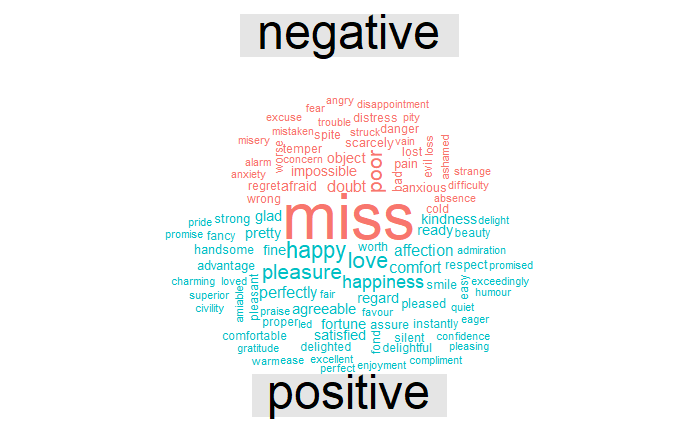

```r
library(reshape2)
austenTidyBooks%>%
inner_join(get_sentiments("bing"))%>%
count(word,sentiment,sort = TRUE)%>%
acast(word~sentiment,value.var = "n",fill=0)%>%
comparison.cloud(colors = c("#F8766D","#00BFC4"),max.words = 100)
```

#4.3 finding words characteristic to documents tf: term frequency: the more frequent a term is, the more popular it is

idf: inverse document frequency: the value increase the rarer the term is

```r
austenTFIDF <- austenTidyBooks%>%
count(book,word,sort = TRUE)%>%
bind_tf_idf(word,book,n)%>%
arrange(desc(tf_idf))
austenTFIDF
```

| book | word | n | tf | idf | tf_idf |
| --- | --- | --- | --- | --- | --- |
| Sense & Sensibility | elinor | 623 | 1.714836e-02 | 1.7917595 | 0.0307257404 |
| Sense & Sensibility | marianne | 492 | 1.354253e-02 | 1.7917595 | 0.0242649507 |
| Emma | emma | 786 | 1.680385e-02 | 1.0986123 | 0.0184609141 |
| Mansfield Park | crawford | 493 | 1.027769e-02 | 1.7917595 | 0.0184151396 |
| Pride & Prejudice | darcy | 373 | 1.001450e-02 | 1.7917595 | 0.0179435720 |
| Persuasion | elliot | 254 | 9.965474e-03 | 1.7917595 | 0.0178557323 |
| Emma | weston | 389 | 8.316408e-03 | 1.7917595 | 0.0149010034 |
| Northanger Abbey | tilney | 196 | 8.234602e-03 | 1.7917595 | 0.0147544263 |
| Pride & Prejudice | bennet | 294 | 7.893465e-03 | 1.7917595 | 0.0141431908 |
| Emma | knightley | 356 | 7.610903e-03 | 1.7917595 | 0.0136369080 |

[output cut: 990 more lines]

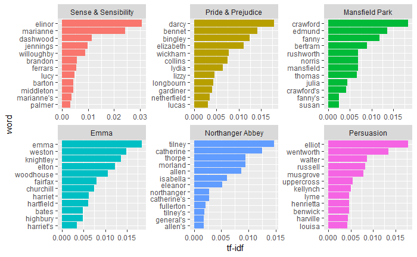

```r
austenTFIDF%>%
group_by(book)%>%
top_n(12,tf_idf)%>%
ungroup()%>%
mutate(word = reorder(word,tf_idf))%>%
ggplot(aes(word,tf_idf,fill=book))+geom_col(show.legend=FALSE)+facet_wrap(~book,scales="free")+
ylab("tf-idf")+coord_flip()
```